# Sensitivity of RepeatMasker recovery rate to the reciprocal-overlap threshold

Ting-Hsuan Chen

05 November, 2026

Revision item 26 (R3-minor#10). The Fig. 5 recovery rate counts a simulated TE as recovered when a RepeatMasker hit overlaps it reciprocally by >= 80%. The same RepeatMasker output (four Fig. 3D scenarios, replicates 1-5) is re-evaluated at 50%, 70%, 80% and 90% reciprocal overlap (`16_tair10_overlap_threshold_sweep.sh`). Base-pair-level recall and precision, which need no threshold, are reported in `25.1_item23_28_benchmark_repeatmasker.Rmd`.

## 1. Load recovery tables

```
## 80% sweep identical to the Fig. 5 evaluation: TRUE
```

## 2. Overall recovery rate by threshold

Overall recovery rate (pooled over bins) by reciprocal-overlap threshold (mean and SD of 5 replicates).

| scenario | rate_mean_50% | rate_sd_50% | rate_mean_70% | rate_sd_70% | rate_mean_80% | rate_sd_80% | rate_mean_90% | rate_sd_90% |
| --- | --- | --- | --- | --- | --- | --- | --- | --- |
| scenario1 | 0.868 | 0.003 | 0.862 | 0.003 | 0.857 | 0.003 | 0.840 | 0.004 |
| scenario2 | 0.710 | 0.007 | 0.697 | 0.007 | 0.688 | 0.007 | 0.665 | 0.007 |
| scenario3 | 0.852 | 0.002 | 0.849 | 0.002 | 0.845 | 0.003 | 0.826 | 0.002 |
| scenario4 | 0.930 | 0.004 | 0.928 | 0.004 | 0.924 | 0.004 | 0.912 | 0.004 |

Saved file name: overlap_threshold_overall.csv

## 3. Recovery by identity and integrity slice

Pooled recovery rate of each identity (or integrity) slice within a replicate, then mean and SD across replicates, as in the Fig. 5 marginal bar plots. Slices are shown when they contain at least one simulated TE in every replicate.

Largest change of a slice’s recovery rate relative to the 80% threshold.

| scenario | dimension | max_gain_at_50 | max_loss_at_90 |
| --- | --- | --- | --- |
| scenario1 | Identity | 0.108 | -0.048 |
| scenario1 | Integrity | 0.017 | -0.042 |
| scenario2 | Identity | 0.105 | -0.045 |
| scenario2 | Integrity | 0.026 | -0.038 |
| scenario3 | Identity | 0.101 | -0.055 |
| scenario3 | Integrity | 0.016 | -0.044 |
| scenario4 | Identity | 0.006 | -0.017 |
| scenario4 | Integrity | 0.018 | -0.041 |

Saved file names: overlap_threshold_by_slice.csv, overlap_threshold_by_slice_delta.csv

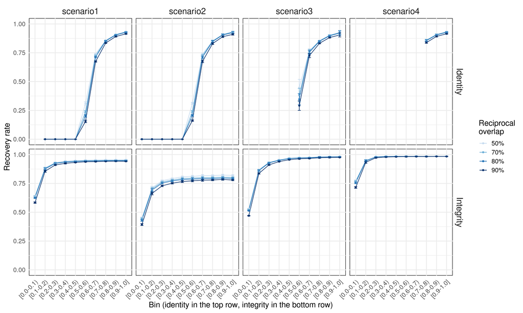

Saved file name: overlap_threshold_by_slice.png

## 4. Notes

- The evaluation is strand- and family-agnostic, as in Fig. 5: any RepeatMasker hit with the required reciprocal overlap counts. Family and superfamily accuracy are in `25.1_item23_28_benchmark_repeatmasker.Rmd` (scenario 1).
- Lower thresholds accept hits that cover only part of a fragmented copy, or hits that extend well beyond it; higher thresholds require nearly exact boundaries.